# Statistical Learning Hw3

Ding Zepeng,18307110088

2020/10/20

# 1、读入数据及汇总统计

```r
houserent <- read.csv("data.csv", header = T)   # 读入CSV文件
summary(houserent)   # 进行汇总
```

```
##       rent         bedroom        livingroom      bathroom          area
##  Min.   :1150   Min.   :2.000   Min.   :1.00   Min.   :1.000   Min.   : 5.00
##  1st Qu.:2240   1st Qu.:2.000   1st Qu.:1.00   1st Qu.:1.000   1st Qu.:10.00
##  Median :2690   Median :3.000   Median :1.00   Median :1.000   Median :12.00
##  Mean   :2798   Mean   :2.996   Mean   :1.01   Mean   :1.027   Mean   :12.85
##  3rd Qu.:3230   3rd Qu.:4.000   3rd Qu.:1.00   3rd Qu.:1.000   3rd Qu.:15.00
##  Max.   :6460   Max.   :5.000   Max.   :2.00   Max.   :2.000   Max.   :30.00
##
##    room       floor_grp    subway        region         heating
##  次卧:2860   低楼层:1679   否: 815   朝阳   :1317   集中供暖:4197
##  主卧:2289   高楼层:1592   是:4334   通州   : 819   自采暖  : 952
##              中楼层:1878             昌平   : 702
##                                      丰台   : 581
##                                      海淀   : 424
##                                      大兴   : 361
##                                      (Other): 945
```

# 2、总体月租金直方图及解读

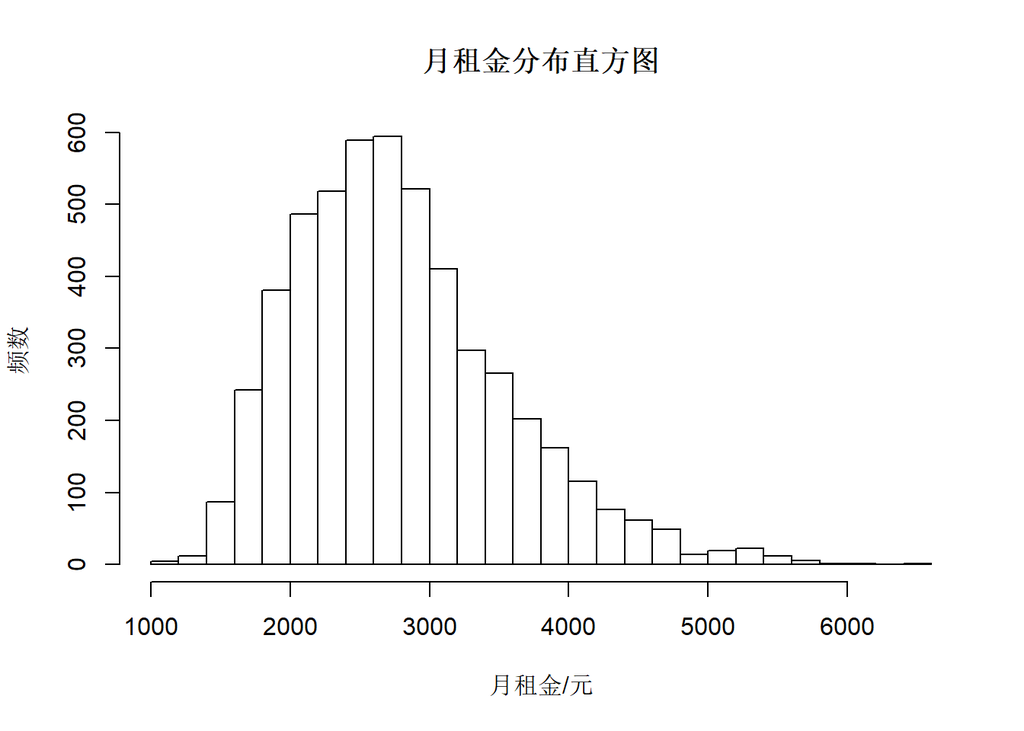

```r
# 绘制月租金分布直方图，适当选取breaks值
hist(houserent$rent, breaks = 30, xlab = "月租金/元", ylab = "频数", main = "月租金分布直方图")
```

- 解读：总体而言北京市住房月租金（因变量）呈现**右偏分布**，如上图所示。月租金多集中于1800-3400区域，鲜有极高的租金值；根据上一小节汇总统计，月租金中位值为2690元，平均值为2798元，均值略高于中位值也反应出分布的右偏性（少量极高样本值拉高了平均值）。最高的月租金对应朝阳区一间27平米中楼层主卧，附近有地铁、集中供暖：也就是说其优秀的房屋地理位置、面积及房间条件配置等造成了其高昂的月租金。整体情况来看，有75%的住房月租金低于3230元，这个数值是最高月租金6460的一半。

# 3、不同城区租房平均价格分析

```r
# 使用聚合函数对平均租金进行按城区的分组统计
meantable <- aggregate(x = houserent$rent, by = list(houserent$region), FUN = mean)
colnames(meantable) <- c("region", "average rent")
# 依照平均租金进行排序，并展示
meantable <- meantable[order(meantable$`average rent`, decreasing = T),]
meantable
```

```
##    region average rent
## 11   西城     3784.792
## 7    海淀     3490.920
## 2    朝阳     3302.103
## 4    东城     3262.872
## 8  石景山     2819.845
## 6    丰台     2734.286
## 1    昌平     2693.376
## 10   通州     2327.216
## 3    大兴     2241.136
## 9    顺义     2111.497
## 5    房山     1751.257
```

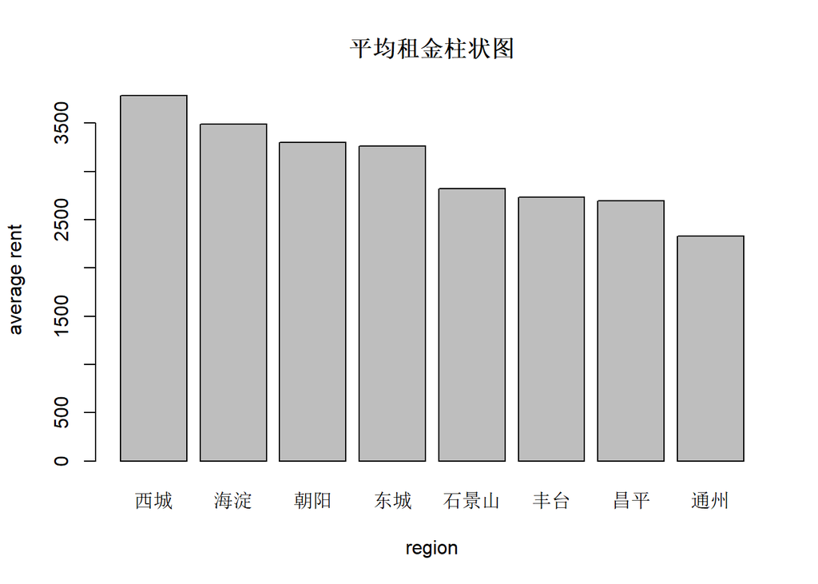

```r
# 提取平均租金最高的八组数据并绘制降序柱状图
highdata <- meantable[1:8,]
barplot(highdata[,2], names.arg = highdata[,1], main = "平均租金柱状图", xlab = "region", ylab = "average rent")
```

- 分析：由租金均值数据及降序柱状图可以看出，**不同城区的月租金均值不同、总体而言越靠近中心/越繁华的城区平均月租金越高**。由降序柱状图可以看出，在平均租金最高的8个城区内：西城区平均租金“独占鳌头”且领先其他城区较多；海淀、朝阳和东城区的月租金相差不多、可认为是“第二梯队”；而石景山、丰台、昌平的平均租金相差不大，但与之前“第二梯队”的城区相差较为明显，可认为是“第三梯队”；通州区的平均月租金较之前城区降低较多，可认为属于“第四梯队”。通州区与西城区的平均月租金差异达到了1450元左右，可以看出不同城区（表征着不同地理位置、经济发展程度）间的平均月租金差异还是比较明显的。

# 4、月租金——城区分组箱线图

```r
# 用聚合函数对租金中位值进行按城区分组统计
mediantable <- aggregate(x = houserent$rent, by = list(houserent$region), FUN = median)
colnames(mediantable) <- c("region", "median rent")
mediantable
```

```
##    region median rent
## 1    昌平        2660
## 2    朝阳        3190
## 3    大兴        2190
## 4    东城        3160
## 5    房山        1700
## 6    丰台        2700
## 7    海淀        3375
## 8  石景山        2830
## 9    顺义        2070
## 10   通州        2290
## 11   西城        3815
```

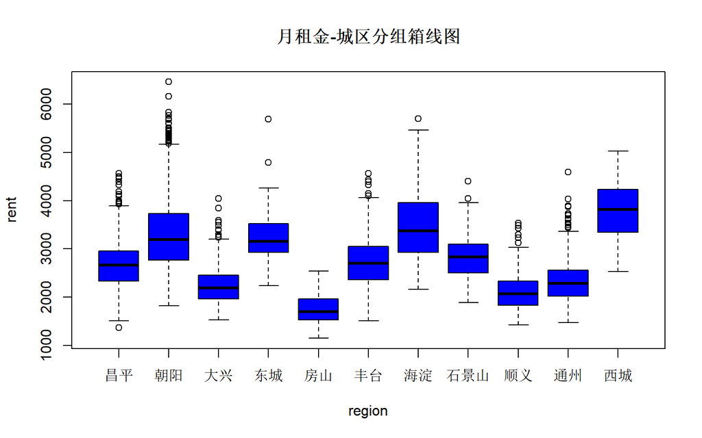

```r
# 绘制分组箱线图
boxplot(houserent$rent ~ houserent$region, xlab = "region", ylab = "rent", main = "月租金-城区分组箱线图", col = 'blue')
```

- 分析解读：分组箱线图不仅能看出各城区间月租金中位值的差异，还可以比较不同城区间月租金分布情况的差异。类似上一小节分析，不同城区间的住房月租金相差较为明显，大致上通过中位月租金值可以将城区分为“西城”，“朝阳、东城、海淀”，“石景山、丰台、昌平”，“通州、大兴、顺义、房山”四个梯队，中位月租金水平依次递减，其中月租金中位值最低的房山区(1700元)不足最高的西城区(3800元)的一半。**总体而言，地理位置越靠近城中心、经济越繁华的城区房屋中位月租金越高，与生活经验相符合**。  
  此外，根据箱线宽度，可以看出西城、海淀、朝阳的住房月租金在各自城区内的差异也较大，而其他城区内住房月租金分布相对而言比较集中（差异不太大）。推测这种现象是由于靠近中心较为发达的城区内部发展程度、便捷或是福利程度差异较大导致的，比如海淀区的学区房整体而言要比非学区房租金高、高档小区整体而言要比旧居民住宅小区租金高等。另外，除西城、房山外的其他城区月租金都存在少量极端值，比如样本中最高的月租金(6400元)并不是在中位值最高的西城区、而是在朝阳区，且高出该区中位水平(3190元)一倍多。这也说明**月租金高低并不只与城区差异有关，还受到其他很多因素的影响**。
- 但是，仅根据目前的描述性分析，并不能断定城区对于住房月租金有着统计学意义上的显著影响，还需要通过回归建模进行客观分析。

# 5、进行线性回归建模

- 首先建立多元线性回归模型，模型表达式如下：
  $$Y = \beta_0\ +\beta_1 X_1\ + ... +\ \beta_9 X_9\ + \epsilon \\\
  E(Y) = \beta_0\ +\beta_1 X_1\ + ... +\ \beta_9 X_9\$$
  其中$Y$为因变量rent，其余均为自变量，分别用$X_1\sim X_9$表示.

```r
# 按要求为因子类型指定基准组
houserent$room <- factor(houserent$room, levels = c("次卧", "主卧"))
houserent$floor_grp <- factor(houserent$floor_grp, c("低楼层", "高楼层", "中楼层"))
houserent$subway <- factor(houserent$subway, c("否", "是"))
houserent$region <- factor(houserent$region, c("石景山", "昌平", "朝阳", "大兴", "东城", "房山", "丰台", "海淀", "顺义", "通州", "西城"))
houserent$heating <- factor(houserent$heating, c("自采暖", "集中供暖"))

# 以月租金为因变量建模
lm.fit1 <- lm(rent ~ ., data = houserent)
summary(lm.fit1)   # 查看回归结果
```

```
##
## Call:
## lm(formula = rent ~ ., data = houserent)
##
## Residuals:
##      Min       1Q   Median       3Q      Max
## -1617.48  -275.26   -23.21   248.40  2967.39
##
## Coefficients:
##                   Estimate Std. Error t value Pr(>|t|)
## (Intercept)     1593.22405   79.93979  19.930  < 2e-16 ***
## bedroom          -90.55187    8.73965 -10.361  < 2e-16 ***
## livingroom      -168.01859   71.84304  -2.339 0.019390 *
## bathroom         182.10825   43.63344   4.174 3.05e-05 ***
## area              76.69198    1.96317  39.065  < 2e-16 ***
## room主卧           0.08443   16.57165   0.005 0.995935
## floor_grp高楼层  -24.98532   15.95019  -1.566 0.117303
## floor_grp中楼层  -55.59610   15.29704  -3.634 0.000281 ***
## subway是         280.44440   17.73655  15.812  < 2e-16 ***
## region昌平        57.19973   34.07111   1.679 0.093245 .
## region朝阳       631.69500   31.69727  19.929  < 2e-16 ***
## region大兴      -421.98157   37.42529 -11.275  < 2e-16 ***
## region东城       565.01670   55.05629  10.263  < 2e-16 ***
## region房山      -811.82173   45.02264 -18.031  < 2e-16 ***
## region丰台       117.59678   34.57808   3.401 0.000677 ***
## region海淀       878.86347   36.51087  24.071  < 2e-16 ***
## region顺义      -450.95937   39.11271 -11.530  < 2e-16 ***
## region通州      -373.00568   32.65046 -11.424  < 2e-16 ***
## region西城       938.86226   54.33181  17.280  < 2e-16 ***
## heating集中供暖  155.79086   17.13452   9.092  < 2e-16 ***
## ---
## Signif. codes:  0 '***' 0.001 '**' 0.01 '*' 0.05 '.' 0.1 ' ' 1
##
## Residual standard error: 454.1 on 5129 degrees of freedom
## Multiple R-squared:  0.6466, Adjusted R-squared:  0.6453
## F-statistic: 493.9 on 19 and 5129 DF,  p-value: < 2.2e-16
```

- 模型F检验的p值很小，说明**整体而言回归系数显著性较好**；Adjusted R-square为0.6453，模型对因变量（月租金）的解释作用比较明显
- 解读：**各定量自变量的回归系数表示在控制其他自变量不变的前提下，因变量（租金）的期望值对于该自变量的敏感程度：回归系数绝对值越大则越敏感**。例如，租赁房间面积（area）的回归系数约为76.7，这表示在控制其他自变量不变的情况下租赁房间每增加1平方米，月租金的期望值会增加76.7元；当定量自变量回归系数为负值时，则表示在模型中因变量期望值与该自变量呈现负相关关系，例如卧室数（bedroom）的回归系数约为-90.6，这表示控制其他自变量不变的情况下租赁房间卧室数每增加一个，月租金期望值会减少90.6元。这是合理的，反映出了租住者希望共同租客更少的偏好。 对四个定量自变量分析，发现其均对租金期望值有较显著的影响，其中（当控制其他变量不变时）租金期望值对卫生间数（bathroom）最为敏感，且与卫生间数、租赁房间面积正相关，与卧室数、客厅数负相关。从系数正负与大小可以推断， 租住者有希望面积更大、共用卫生间更多、公共租客（反映在卧室数、客厅数）更少的偏好。
- **各定性变量（对应转换成的哑变量）的回归系数则表示其他自变量不变时，该定性变量取该分类水平时，因变量的值平均比基准组高多少**。例如，城区（region）变量的基准组是石景山区，则昌平区的回归系数57.2则表示其他自变量不变时，昌平区月租金期望值比石景山区高57.2元；而大兴区的回归系数-421.99则表示其他自变量不变时，大兴区月租金期望值比石景山区低421.99元。 对五个定性自变量分析，可以发现（均以控制其他自变量不变为前提）：房间类型（room）是主卧还是次卧对月租金影响很小；楼层(floor_grp)的差异导致的月租金差异也较小，高、中楼层的月租金期望值比低楼层略低；靠近地铁（subway）对于月租金均值的有较大的正向影响，相对与不靠近地铁的租房月租金均值高出280.5元；月租金的城区间差异较为明显；供暖方式（heating）也有较大影响，集中供暖的月租金期望值比自供暖高出155.8元.
- 综上所述，房间类型、所在楼层对月租金期望值的影响较小，其他因素则具有一定的影响。
- 此外，**单个系数假设检验的p值反映了该系数的显著水平**，即对应自变量对因变量解释程度的显著水平；p值越低，该显著性水平越高。

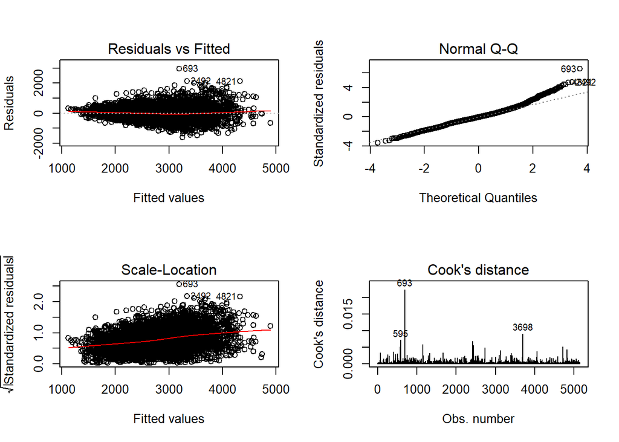

```r
 # 进行模型诊断，绘图
par(mfrow = c(2, 2))
plot(lm.fit1, which = c(1:4))
```

+ 分析：左上角为残差与拟合值的散点图，若因变量和自变量呈现线性相关关系，则残差值与拟合值不会有任何系统关联；图中所示残差并不随拟合值变化而呈现规律性变化，因此**基本满足线性假设**。但左下角的位置尺度图中随着拟合值增大，标准化残差呈现升高的规律，而如果满足同方差假设则水平线周围的点应无规律随机分布，因此表明模型**存在一定的异方差问题**。右上角为正态Q-Q图，模型中残差项在较大值的部分偏离了45°直线，因此**较大程度上偏离了正态分布**。右下角的Cook距离图中样本点的Cook距离均很小，最大值低于0.05（远小于1），因此可认为**样本中不存在强影响点**。
+ 针对以上问题，可以通过对因变量进行对数变换，重新拟合回归模型，如下。
$$log(Y) = \beta_0\ +\beta_1 X_1\ + ... +\ \beta_9 X_9\ + \epsilon$$

```r
# 将因变量进行对数变换
houserent$logrent <- log(houserent$rent)
# 建立对数线性模型，剔除原rent变量
lm.fitlog <- lm(logrent ~ .-rent, data = houserent)
# 查看回归结果
summary(lm.fitlog)
```

```
##
## Call:
## lm(formula = logrent ~ . - rent, data = houserent)
##
## Residuals:
##      Min       1Q   Median       3Q      Max
## -0.66036 -0.09473  0.00008  0.09992  0.69552
##
## Coefficients:
##                  Estimate Std. Error t value Pr(>|t|)
## (Intercept)      7.526630   0.026713 281.755  < 2e-16 ***
## bedroom         -0.036754   0.002920 -12.585  < 2e-16 ***
## livingroom      -0.044047   0.024008  -1.835  0.06661 .
## bathroom         0.064026   0.014581   4.391 1.15e-05 ***
## area             0.025198   0.000656  38.410  < 2e-16 ***
## room主卧         0.004432   0.005538   0.800  0.42355
## floor_grp高楼层 -0.010528   0.005330  -1.975  0.04829 *
## floor_grp中楼层 -0.020409   0.005112  -3.992 6.63e-05 ***
## subway是         0.105890   0.005927  17.866  < 2e-16 ***
## region昌平       0.010431   0.011385   0.916  0.35961
## region朝阳       0.197869   0.010592  18.681  < 2e-16 ***
## region大兴      -0.178279   0.012506 -14.255  < 2e-16 ***
## region东城       0.188609   0.018398  10.252  < 2e-16 ***
## region房山      -0.395786   0.015045 -26.307  < 2e-16 ***
## region丰台       0.032436   0.011555   2.807  0.00502 **
## region海淀       0.274740   0.012201  22.518  < 2e-16 ***
## region顺义      -0.201067   0.013070 -15.384  < 2e-16 ***
## region通州      -0.153112   0.010911 -14.033  < 2e-16 ***
## region西城       0.285027   0.018156  15.699  < 2e-16 ***
## heating集中供暖  0.042917   0.005726   7.495 7.75e-14 ***
## ---
## Signif. codes:  0 '***' 0.001 '**' 0.01 '*' 0.05 '.' 0.1 ' ' 1
##
## Residual standard error: 0.1517 on 5129 degrees of freedom
## Multiple R-squared:  0.6759, Adjusted R-squared:  0.6747
## F-statistic:   563 on 19 and 5129 DF,  p-value: < 2.2e-16
```

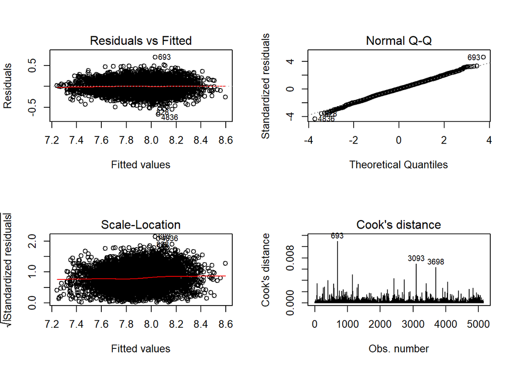

```r
par(mfrow = c(2, 2))
plot(lm.fitlog, which = c(1:4))    # 进行模型诊断，绘图
```

- 分析：对数线性拟合模型中，F检验的p值亦较小、调整后的R方略高于线性模型，**整体而言回归系数显著性较好**。根据模型回归诊断图可以看出，**异方差及非正态性都得到了很好的改善**。
- 系数解读：在对数线性回归模型中，自变量的回归系数所表示的含义与线性模型不同，可以理解为“**增长率**”：
  $$\partial\ log(y)\ / \partial x = \partial y/(y \times \partial x)$$
- 对于模型中的四个**定量自变量**而言，其回归系数表示在控制其他自变量不变的同时，该自变量每增加一单位，因变量平均而言增加的比例。对本对数模型而言，控制其他因素不变时： – 每增加一个卧室(表征着共同租客的增加)，月租金平均减少3.68%； – 每增加一间客厅，月租金平均减少4.4%； – 每多一间卫生间，月租金平均增加6.4%； – 租住面积每增加一平米，月租金平均增加2.52%.
- 对于模型中的五个**定性自变量**而言，其回归系数表示其他因素不变的同时，自变量取该分类某个水平时，因变量平均相对于基准水平增加的比例。对本对数模型而言，控制其他因素不变时： – 房间类型主卧比次卧的月租金平均贵0.44%（差异不明显）； – 高楼层房间月租金平均比低楼层低1.05%，中楼层月租金平均比低楼层低2.04%；楼层类型导致的月租金差异较小； – 地铁房比非地铁房的月租金平均高出10.59%； – 城区见平均月租金的差异较为明显，其中西城区平均月租金最高，高出石景山区28.5%；房山区平均月租金最低，相比于石景山区减少了39.58%. – 集中供暖的房间月租金平均比自供暖房间高出4.29%

```r
library(DAAG)     # 诊断模型是否有多重共线性
vif(lm.fitlog)
```

```
##         bedroom      livingroom        bathroom            area        room主卧
##          1.2181          1.2150          1.2314          1.6725          1.6935
## floor_grp高楼层 floor_grp中楼层        subway是      region昌平      region朝阳
##          1.3571          1.3540          1.0467          3.4136          4.7764
##      region大兴      region东城      region房山      region丰台      region海淀
##          2.2805          1.3568          1.7352          2.9891          2.5157
##      region顺义      region通州      region西城 heating集中供暖
##          2.1878          3.5612          1.3489          1.1050
```

- 模型各自变量的VIF值均低于10，可认为**自变量间不存在多重共线性**。

# 6、应用BIC准则对变量进行选择

```r
n <- nrow(houserent)
# BIC准则对线性回归模型进行选择
lm.bic1 <- step(lm.fit1, direction = "both", k = log(n), trace = F)
summary(lm.bic1)
```

```
##
## Call:
## lm(formula = rent ~ bedroom + bathroom + area + subway + region +
##     heating, data = houserent)
##
## Residuals:
##      Min       1Q   Median       3Q      Max
## -1611.79  -271.91   -25.92   248.37  2980.50
##
## Coefficients:
##                 Estimate Std. Error t value Pr(>|t|)
## (Intercept)     1440.449     59.027  24.403  < 2e-16 ***
## bedroom          -91.457      8.547 -10.701  < 2e-16 ***
## bathroom         141.751     40.550   3.496 0.000477 ***
## area              76.527      1.533  49.930  < 2e-16 ***
## subway是         281.206     17.743  15.849  < 2e-16 ***
## region昌平        58.700     34.104   1.721 0.085276 .
## region朝阳       634.860     31.729  20.009  < 2e-16 ***
## region大兴      -418.866     37.422 -11.193  < 2e-16 ***
## region东城       565.767     55.124  10.264  < 2e-16 ***
## region房山      -808.478     45.011 -17.962  < 2e-16 ***
## region丰台       119.461     34.606   3.452 0.000561 ***
## region海淀       880.960     36.546  24.106  < 2e-16 ***
## region顺义      -456.412     39.038 -11.691  < 2e-16 ***
## region通州      -372.159     32.685 -11.386  < 2e-16 ***
## region西城       935.072     54.387  17.193  < 2e-16 ***
## heating集中供暖  154.970     17.150   9.036  < 2e-16 ***
## ---
## Signif. codes:  0 '***' 0.001 '**' 0.01 '*' 0.05 '.' 0.1 ' ' 1
##
## Residual standard error: 454.7 on 5133 degrees of freedom
## Multiple R-squared:  0.6453, Adjusted R-squared:  0.6443
## F-statistic: 622.7 on 15 and 5133 DF,  p-value: < 2.2e-16
```

```r
# BIC准则对对数线性回归模型进行选择
lm.bic2 <- step(lm.fitlog, direction = "both", k = log(n), trace = F)
summary(lm.bic2)
```

```
##
## Call:
## lm(formula = logrent ~ bedroom + bathroom + area + subway + region +
##     heating, data = houserent)
##
## Residuals:
##      Min       1Q   Median       3Q      Max
## -0.65849 -0.09480 -0.00018  0.09992  0.69651
##
## Coefficients:
##                   Estimate Std. Error t value Pr(>|t|)
## (Intercept)      7.4828542  0.0197277 379.307  < 2e-16 ***
## bedroom         -0.0373880  0.0028564 -13.089  < 2e-16 ***
## bathroom         0.0527619  0.0135526   3.893  0.00010 ***
## area             0.0254751  0.0005123  49.732  < 2e-16 ***
## subway是         0.1059632  0.0059298  17.869  < 2e-16 ***
## region昌平       0.0106945  0.0113982   0.938  0.34815
## region朝阳       0.1990899  0.0106043  18.774  < 2e-16 ***
## region大兴      -0.1767436  0.0125070 -14.132  < 2e-16 ***
## region东城       0.1891943  0.0184233  10.269  < 2e-16 ***
## region房山      -0.3940076  0.0150433 -26.192  < 2e-16 ***
## region丰台       0.0332367  0.0115660   2.874  0.00407 **
## region海淀       0.2755829  0.0122142  22.563  < 2e-16 ***
## region顺义      -0.2020836  0.0130473 -15.489  < 2e-16 ***
## region通州      -0.1526145  0.0109240 -13.971  < 2e-16 ***
## region西城       0.2834162  0.0181772  15.592  < 2e-16 ***
## heating集中供暖  0.0426056  0.0057316   7.433 1.23e-13 ***
## ---
## Signif. codes:  0 '***' 0.001 '**' 0.01 '*' 0.05 '.' 0.1 ' ' 1
##
## Residual standard error: 0.152 on 5133 degrees of freedom
## Multiple R-squared:  0.6747, Adjusted R-squared:  0.6737
## F-statistic: 709.6 on 15 and 5133 DF,  p-value: < 2.2e-16
```

- 解读：从回归结果可以看出，不论是对线性模型、还是对对数线性模型使用BIC准则进行逐步回归后，**留下的自变量均对因变量有显著的影响（单个系数假设检验的p值较小）**，且两种BIC回归均剔除了livingroom（客厅数）、room（卧室类型）、floor_grp（楼层类型），留下了剩下的自变量。
- 留下自变量的系数估计值与原模型略有区别，对系数的解读类似之前；用BIC准则进行变量选择后的模型的Adjusted R-square与之前基本相同，模型对因变量（月租金）的解释作用比较明显；模型F检验的p值很小，说明整体而言回归系数显著性较好。

# 7、交叉验证及模型评估

```r
## 对BIC准则选择的线性模型进行五折交叉验证
# 使用DAAG包的cv.lm()函数
cv.lm1 <- cv.lm(data = houserent, lm.bic1, m = 5, printit = F, seed = 123)
```

[figure not shown]

```r
sqrt(attr(cv.lm1, "ms"))     # 均方根误差
```

```
## [1] 455.5569
```

```r
# 自编函数
predcv <- function(dat, k){
  ind = sample(1:k, nrow(dat), replace = T)
  pred_cv = rep(0, nrow(dat))
  for(i in 1:k){
    ii = which(ind == i)
    obj = lm(rent ~ .-logrent, data = dat[-ii,])
    pred_cv[ii] = predict(obj, houserent[ii,])
  }
  rmse = sqrt(mean((pred_cv - dat$rent)^2))
  return(list(pred_cv = pred_cv, rmse = rmse))
}

set.seed = 1234
pred_cv = predcv(dat = houserent, k=5)
pred_cv$rmse
```

```
## [1] 454.9869
```

- 解读：通过交叉验证的均方根误差可以看出，经过BIC准则变量选择后的线性模型预测的效果较好（但仍有很大改善空间），预测的均方根误差低于月租金一个数量级，大概是月租金中位数(2690)的17%。

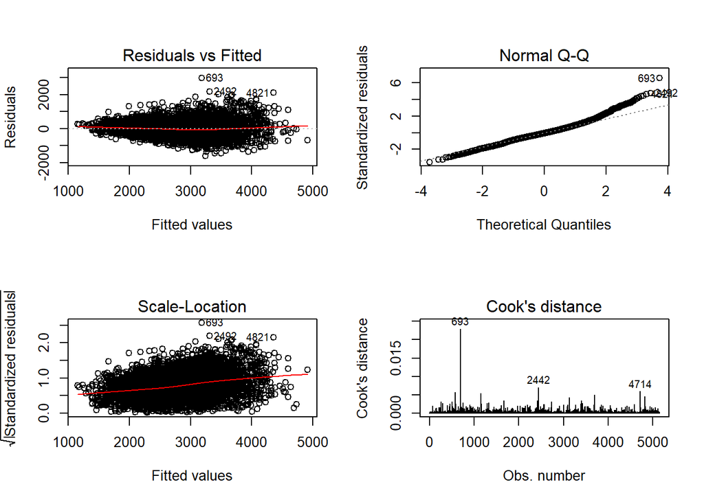

```r
# 模型诊断
par(mfrow = c(2, 2))
plot(lm.bic1, which = c(1:4))
```

- BIC准则进行变量选择后的线性模型评估： –左上角为残差与拟合值的散点图，若因变量和自变量呈现线性相关关系，则残差值与拟合值不会有任何系统关联；图中所示残差并不随拟合值变化而呈现规律性变化，因此**基本满足线性假设**。 –左下角的位置尺度图中随着拟合值增大，标准化残差呈现升高的规律，而如果满足同方差假设则水平线周围的点应无规律随机分布，因此表明模型**存在一定的异方差问题**。 –右上角为正态Q-Q图，模型中残差项在较大值的部分偏离了45°直线，因此**较大程度上偏离了正态分布**。 –右下角的Cook距离图中样本点的Cook距离均很小，最大值低于0.05（远小于1），因此可认为**样本中不存在强影响点**。
- 综上可以看出，BIC变量选择后的线性模型仍存在和之前线性模型类似的问题，可以尝试因变量对数变换后再应用BIC准则，其五折交叉验证及模型结果如下：

```r
## 对BIC准则选择的对数线性模型进行五折交叉验证
# 使用DAAG包的cv.lm()函数
cv.lm1 <- cv.lm(data = houserent, lm.bic2, m = 5, printit = FALSE, seed = 123)
```

[figure not shown]

```r
sqrt(attr(cv.lm1, "ms"))       # 均方根误差
```

```
## [1] 0.1522928
```

```r
# 自编函数
predcv <- function(dat, k){
  ind = sample(1:k, nrow(dat), replace = T)
  pred_cv = rep(0, nrow(dat))
  for(i in 1:k){
    ii = which(ind == i)
    obj = lm(logrent ~ .-rent, data = dat[-ii,])
    pred_cv[ii] = predict(obj, houserent[ii,])
  }
  rmse = sqrt(mean((pred_cv - dat$logrent)^2))
  return(list(pred_cv = pred_cv, rmse = rmse))
}

set.seed = 1234
pred_cv = predcv(dat = houserent, k=5)
pred_cv$rmse
```

```
## [1] 0.1520456
```

- 解读：通过交叉验证的均方根误差可以看出，经过BIC准则变量选择后的对数线性模型预测的效果较好，略优于相应的线性模型的预测效果，预测的均方根误差低于log(rent)一个数量级，大概是月租金中位数(7.897)的1.9%【但这是对数化后的误差百分比】.

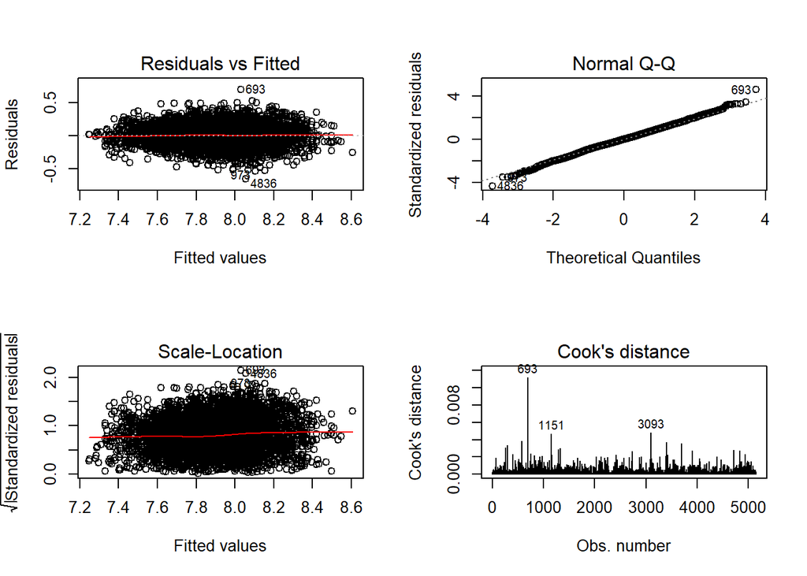

```r
# 模型诊断
par(mfrow = c(2, 2))
plot(lm.bic2, which = c(1:4))
```

- BIC准则进行变量选择后的对数线性模型评估：根据模型回归诊断图可以看出，**异方差及非正态性都得到了很好的改善**，相较于之前的线性模型更优。